# Prevalence and Socio-Demographic Correlates of Body Weight Categories Among Ugandan Women of Reproductive Age

Emmanuel Ariong

2023-12-11

# Introduction

## Background

The shift in disease patterns has been connected with increased body weight burden, becoming a major public health concern in Uganda, as previous studies have assessed overweight or obesity among certain populations. However, little is known about body weight burden (underweight, overweight, and obesity) among women aged 15–49 years.

## Objectives of the study

### Main objective

Therefore, this study was conducted to identify the prevalence and its associated socio-demographic correlates of body weight categories among women of reproductive age in Uganda.

### Specific objectives

1. To determine the association between the body weights and place of residence
2. To determine if the body weights vary with wealth quintiles
3. To determine the relationship between the body weights and the level of education of the respondents.
4. To determine the association between the body weights and the region and marital status.

# Methods

## Data source

This study utilised the data from the sixth’s series of the Ugandan Demographic and Health Survey, conducted in 2016 (2016 UDHS). The 2016 UDHS is a nationally representative sample survey of 20,880 households; 18,506 eligible women in the age range 15–49 years were interviewed with an average of 1,200 complete interviews per domain.

## Description of the Measurement of BMI and Its Classification

BMI is calculated with the metric system as follows:

BMI = Person′s weight (kg) / Person′sheight (m)2

(where kg is kilogrammes and m is metres).

*Note that height is commonly measured in centimetres (cm), and height (cm) is divided by 100 to obtain height in metres (m).*

## Outcome Variable

The outcome variable for this study was **BMI**, which was categorized as underweight, normal, overweight and obese, respectively. According to WHO, Women with BMI < 18.5 kg/m2 were described as underweight, while those with BMI of 18.5-24.9 kg/m2 were described as having normal body weight, those with BMI of 25-29.9 kg/m2 were overweight, and those with BMI ≥ 30 kg/m2 were obese.

## Explanatory Variables

The selected socio-demographic predictor factors incorporated in the analysis are age (15 - 49 years), region (kampala , south buganda , north buganda , busoga , bukedi , bugisu, teso , karamoja, lango, acholi, west nile, bunyoro, tooro, ankole, kigezi), marital status (never married and ever married), education level (no education, primary, secondary and higher (tertiary and university)), Residence(urban and rural),and wealth quintile (lowest, middle and highest).

# Statistical Analysis

## Data Importation and cleaning

### Step 1: Choosing the necessary variables for analysis

| Variable Name | Variable description |
| --- | --- |
| caseid | case identification |
| v012 | respondent’s current age |
| v438 | respondent’s height in centimeters (1 decimal) |
| v437 | respondent’s weight in kilograms (1 decimal) |
| v025 | type of place of residence |
| v024 | region |
| v106 | highest educational level |
| v190 | wealth index combined |
| v501 | current marital status |

### Step 2: Assigning variable names

Assign descriptive names to the newly imported variables and then execute the code below.

### Step 3: Creating new variables for analysis

Under this stage we aim at creating new variables like bmi, wealth and marital status category for easy analysis of the data.

### Step 4: Reveal coded values

Transforming all variables into regular R factors.

## Tabulations and Graphical representation of analysis

### Prevalence of Body Mass Index

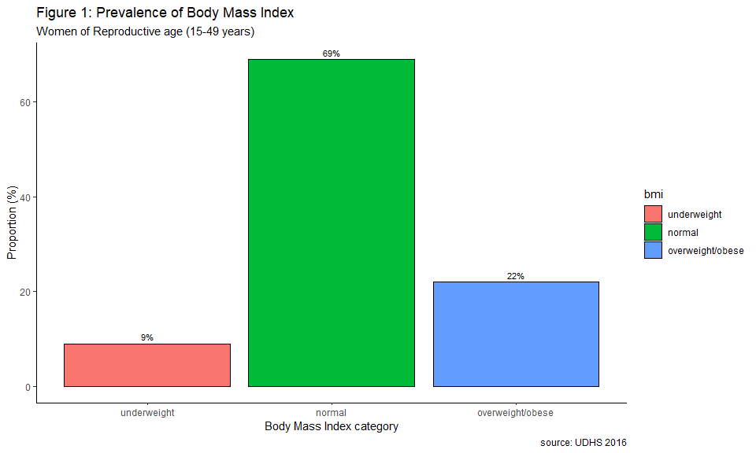

**Figure 1** illustrates the three body weight categories of nutrition among women of reproductive age in Uganda. The bar chart reveals that a majority of the women aged 15–49 years were normal (69%) followed by those in the overweight/obese body weight category (22%).

### Prevalence of Body Mass Index across the age of respondents.

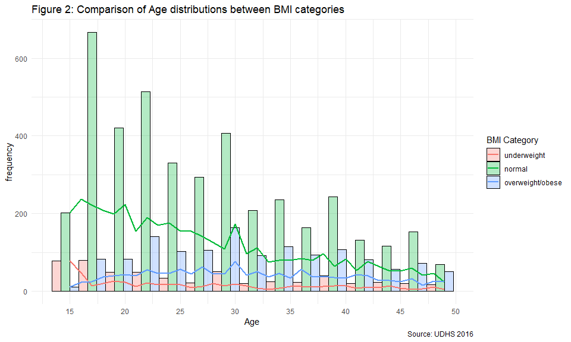

### Place of residence and Education level correlates with the BMI weights

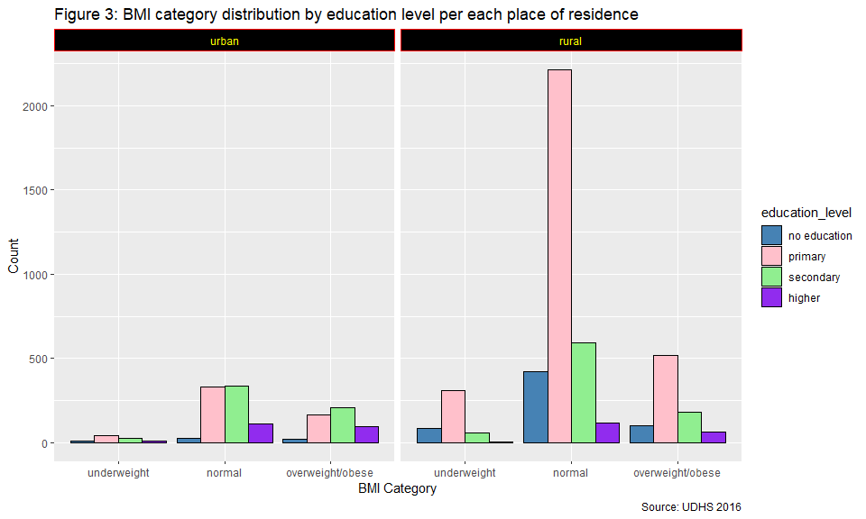

**Figure 3** shows that majority of the normal women from rural areas attended primary as their highest level of education compared to those in urban areas where majority of them attended secondary as their highest level of education.

Majority of the underweight women from rural and urban areas reported to attend primary level as their highest level of education.

The highest number of women in urban areas who are overweight/obese reported to attain secondary level as their highest level of education whereas those in rural areas reported to attend primary as their highest level of education.

### Prevalence of BMI weights across the different regions

| region | underweight (%) | normal (%) | overweight/obese (%) |
| --- | --- | --- | --- |
| kampala | 4 | 54 | 42 |
| south buganda | 5 | 57 | 38 |
| north buganda | 5 | 64 | 32 |
| busoga | 7 | 76 | 17 |
| bukedi | 10 | 73 | 17 |
| bugisu | 9 | 73 | 18 |
| teso | 14 | 73 | 13 |
| karamoja | 31 | 65 | 4 |
| lango | 13 | 76 | 11 |
| acholi | 14 | 77 | 9 |
| west nile | 15 | 76 | 9 |
| bunyoro | 8 | 68 | 25 |
| tooro | 4 | 69 | 28 |
| ankole | 5 | 66 | 29 |
| kigezi | 2 | 67 | 31 |

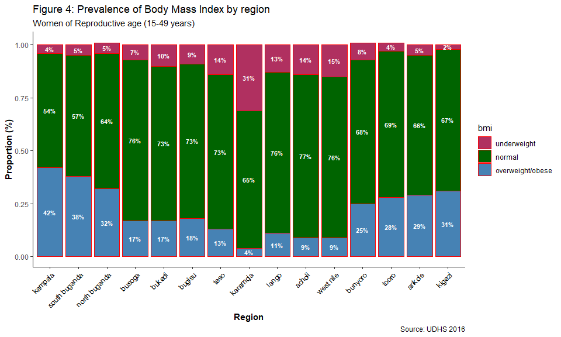